# R Notebook

```r
train.set<-read.csv("fullcasesrpb.csv")
```

```
There were 50 or more warnings (use warnings() to see the first 50)
```

Recoding NDI December 2018 and April 2019

`r`r test.seta$RESPAGE_1825<-test.seta$RESPAGE

```
There were 50 or more warnings (use warnings() to see the first 50)
```

`r`r test.seta$RESPAGE_1825[test.seta$RESPAGE_1825<=25]<-1 test.seta$RESPAGE_1825[test.seta$RESPAGE_1825>=25]<-0 test.seta$RESPAGE_2635<-test.seta$RESPAGE test.seta$RESPAGE_2635[test.seta$RESPAGE_2635<=25]<-0 test.seta$RESPAGE_2635[test.seta$RESPAGE_2635>=36]<-0 test.seta$RESPAGE_2635[test.seta$RESPAGE_2635>=26]<-1 test.seta$RESPAGE_3645<-test.seta$RESPAGE test.seta$RESPAGE_3645[test.seta$RESPAGE_3645<=35]<-0 test.seta$RESPAGE_3645[test.seta$RESPAGE_3645>=46]<-0 test.seta$RESPAGE_3645[test.seta$RESPAGE_3645>=36]<-1 test.seta$RESPAGE_4655<-test.seta$RESPAGE test.seta$RESPAGE_4655[test.seta$RESPAGE_4655<=45]<-0 test.seta$RESPAGE_4655[test.seta$RESPAGE_4655>=56]<-0 test.seta$RESPAGE_4655[test.seta$RESPAGE_4655>=46]<-1 test.seta$RESPAGE_5665<-test.seta$RESPAGE test.seta$RESPAGE_5665[test.seta$RESPAGE_5665<=45]<-0 test.seta$RESPAGE_5665[test.seta$RESPAGE_5665>=66]<-0 test.seta$RESPAGE_5665[test.seta$RESPAGE_5665>=46]<-1 test.seta$RESPAGE_6575<-test.seta$RESPAGE test.seta$RESPAGE_6575[test.seta$RESPAGE_6575<=65]<-0 test.seta$RESPAGE_6575[test.seta$RESPAGE_6575>=76]<-0 test.seta$RESPAGE_6575[test.seta$RESPAGE_6575>=66]<-1 test.seta$RESPAGE_75over<-test.seta$RESPAGE test.seta$RESPAGE_75over[test.seta$RESPAGE_75over<=75]<-0 test.seta$RESPAGE_75over[test.seta$RESPAGE_75over>=76]<-1 test.seta$cap<-test.seta$SETTYPE test.seta$cap[test.seta$cap!=1]<-0 test.seta$urb<-test.seta$SETTYPE test.seta$urb[test.seta$urb!=2]<-0 test.seta$urb[test.seta$urb==2]<-1 test.seta$rur<-test.seta$SETTYPE test.seta$rur[test.seta$rur!=3]<-0 test.seta$rur[test.seta$rur==3]<-1 test.seta$min<-test.seta$SETTYPE test.seta$min[test.seta$min!=4]<-0 test.seta$min[test.seta$min==4]<-1 test.seta$MA<-test.seta$RESPEDU test.seta$MA[test.seta$MA!=6]<-0 test.seta$MA[test.seta$MA==6]<-1 test.seta$bach<-test.seta$RESPEDU test.seta$bach[test.seta$bach!=5]<-0 test.seta$bach[test.seta$bach==5]<-1 test.seta$voc<-test.seta$RESPEDU test.seta$voc[test.seta$voc!=4]<-0 test.seta$voc[test.seta$voc==4]<-1 test.seta$secondary<-test.seta$RESPEDU test.seta$secondary[test.seta$secondary!=3]<-0 test.seta$secondary[test.seta$secondary==3]<-1 test.seta$nineyears<-test.seta$RESPEDU test.seta$nineyears[test.seta$nineyears!=2]<-0 test.seta$nineyears[test.seta$nineyears==2]<-1 test.seta$noeducation<-test.seta$RESPEDU test.seta$noeducation[test.seta$noeducation!=2]<-0 test.seta$noeducation[test.seta$noeducation==2]<-1 test.seta$timewt<-c(126/121) table(test.seta$JOINEU)

```
  -3   -2   -1    0    1
   1    4  203  255 1742
```

`r`r test.seta$JOINEU_r<-test.seta$JOINEU test.seta$JOINEU_r[test.seta$JOINEU_r==-3]<-NA test.seta$GENATO_r<-test.seta$GENATO test.seta$GENATO_r<-(test.seta$GENATO_r+3) test.seta$GENATO_r<-(test.seta$GENATO_r*10) table(test.seta$GENATO_r)

```
  10   20   30   40
  10  241  356 1598
```

`r`r test.seta$JOINEU_r<-(test.seta$JOINEU_r+3) test.seta$three_categories<-(test.seta$GENATO_r+test.seta$JOINEU_r) table(test.seta$three_categories)

```
  11   12   13   14   22   23   24   31   32   33   34   42   43   44
   3    1    1    5  170   10   61    1   12  215  128   20   29 1548
```

`r`r test.seta$three_categories[test.seta$three_categories==11]<-NA test.seta$three_categories[test.seta$three_categories==12]<-1 test.seta$three_categories[test.seta$three_categories==13]<-1 test.seta$three_categories[test.seta$three_categories==14]<-1 test.seta$three_categories[test.seta$three_categories==21]<-1 test.seta$three_categories[test.seta$three_categories==22]<-1 test.seta$three_categories[test.seta$three_categories==23]<-1 test.seta$three_categories[test.seta$three_categories==24]<-1 test.seta$three_categories[test.seta$three_categories==31]<-1 test.seta$three_categories[test.seta$three_categories==32]<-1 test.seta$three_categories[test.seta$three_categories==33]<-0 test.seta$three_categories[test.seta$three_categories==34]<-1 test.seta$three_categories[test.seta$three_categories==41]<-1 test.seta$three_categories[test.seta$three_categories==42]<-1 test.seta$three_categories[test.seta$three_categories==43]<-1 test.seta$three_categories[test.seta$three_categories==44]<-2 table(test.seta$three_categories)

```
   0    1    2
 215  438 1548
```

`r`r test.seta$RESPEDU<-test.set$V22

[output not shown]

`r`r table(test.set$three_categories, knn.pred1)

```
   knn.pred1
       0    1    2
  0    2   53  463
  1   10  216 1131
  2    9  141 3096
```

Correct predictions

`r`r (((2+216+3096)/(2+53+463+10+216+1131+9+141+3096))*100)

```
[1] 64.71392
```

```r
test.set$RESPAGE[test.set$RESPAGE<=-1]<-NA
test.set$SETTYPE[test.set$SETTYPE<=-2]<-NA
test.set$RESPEDU[test.set$RESPEDU<=-1]<-NA
test.set$SETTYPE<-as.factor(test.set$SETTYPE)
test.set$RESPEDU<-as.factor(test.set$RESPEDU)
test.set$three_categories<-as.factor(test.set$three_categories)
model1<-polr(three_categories~RESPAGE+
               SETTYPE+
               RESPEDU, data = test.set)
summary(model1)
```

```
Re-fitting to get Hessian
```

```
Call:
polr(formula = three_categories ~ RESPAGE + SETTYPE + RESPEDU,
    data = test.set)

Coefficients:
            Value Std. Error t value
RESPAGE  -0.01545   0.001708  -9.045
SETTYPE2  0.30228   0.089077   3.394
SETTYPE3  0.43544   0.095221   4.573
SETTYPE4 -1.08427   0.089607 -12.100
RESPEDU2  0.20018   0.162608   1.231
RESPEDU3  0.38001   0.128274   2.962
RESPEDU4  0.44562   0.136314   3.269
RESPEDU5  0.76602   0.140519   5.451
RESPEDU6  0.73701   0.177737   4.147

Intercepts:
    Value    Std. Error t value
0|1  -2.7875   0.1726   -16.1455
1|2  -0.9966   0.1677    -5.9420

Residual Deviance: 8225.773
AIC: 8247.773
(43 observations deleted due to missingness)
```

```
Re-fitting to get Hessian
```

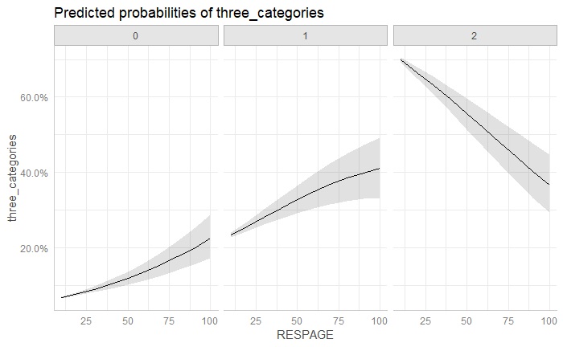

```r
plot(ggpredict(model1, terms = c("RESPAGE")))
```

```
Re-fitting to get Hessian
```

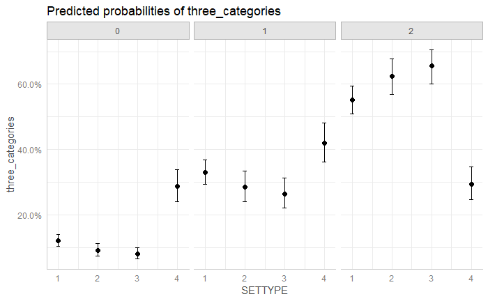

```r
plot(ggpredict(model1, terms = c("SETTYPE")))
```

```r
table(tester$x, tester$predicted)
```

[output not shown]

```
There were 50 or more warnings (use warnings() to see the first 50)
```

```
Re-fitting to get Hessian
```

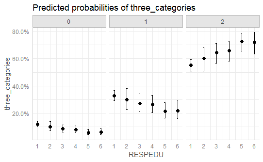

```
Re-fitting to get Hessian
```

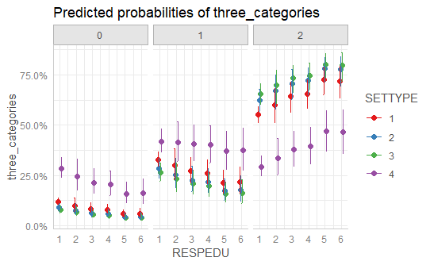

```
Re-fitting to get Hessian
```

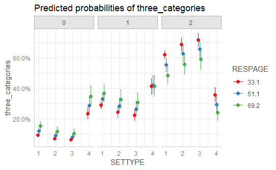